# Modèle disponible sur le site https://www.tensorflow.org/tutorials/images/classification

## Ceci est la mise en application du tutoriel, sur notre jeu de donnée d'image de pneumonie

### Import des librairies necessaires

```python
import matplotlib.pyplot as plt
import numpy as np
import tensorflow as tf

from tensorflow import keras
from keras import layers
from keras.models import Sequential
```

### Préparation des paths vers le dossier d'entrainement et de validation des images

```python
import pathlib

data_dir_train = pathlib.Path('chest_Xray/train')
data_dir_val = pathlib.Path('chest_Xray/val')
```

```python
image_count = len(list(data_dir_train.glob('*/*.jpeg')))
print(image_count)
```

```
5216
```

### Paramètre du dataset

```python
batch_size = 32
img_height = 180
img_width = 180
```

### Création des dataset

```python
train_ds = tf.keras.utils.image_dataset_from_directory(
    data_dir_train,
    labels="inferred",
    seed=123,
    color_mode="grayscale",
    image_size=(img_height, img_width),
    batch_size=batch_size)
val_ds = tf.keras.utils.image_dataset_from_directory(
    data_dir_val,
    labels="inferred",
    seed=123,
    color_mode="grayscale",
    image_size=(img_height, img_width),
    batch_size=batch_size)
```

```
Found 5216 files belonging to 2 classes.
Found 16 files belonging to 2 classes.
```

```python
class_names = train_ds.class_names
print(class_names)
```

```
['NORMAL', 'PNEUMONIA']
```

### Impression d'un échantillon d'images

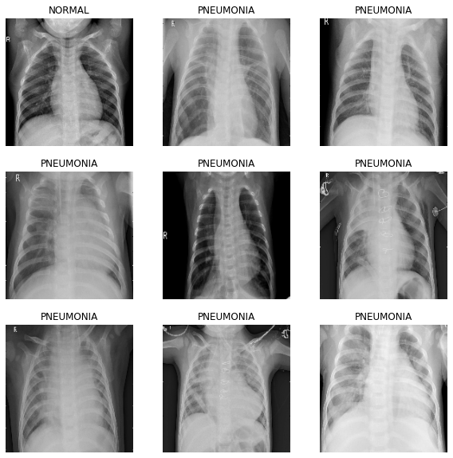

```python
plt.figure(figsize=(10, 10))
for images, labels in train_ds.take(1):
    for i in range(9):
        ax = plt.subplot(3, 3, i + 1)
        plt.imshow(images[i].numpy().astype("uint8"), cmap=plt.cm.gray)
        plt.title(class_names[labels[i]])
        plt.axis("off")
```

### Impression de la taille des données du dataset

```python
for image_batch, labels_batch in train_ds:
    print(image_batch.shape)
    print(labels_batch.shape)
    break
```

```
(32, 180, 180, 1)
(32,)
```

### Mise en mémoire tampon des données pour optimiser les E/S vers le disque

```python
AUTOTUNE = tf.data.AUTOTUNE

train_ds = train_ds.cache().shuffle(1000).prefetch(buffer_size=AUTOTUNE)
val_ds = val_ds.cache().prefetch(buffer_size=AUTOTUNE)
```

### Définition, compilation et résumé du modele et de ses paramètres

```python
num_classes = len(class_names)

model = Sequential([
    layers.Rescaling(1. / 255, input_shape=(img_height, img_width, 1)),
    layers.Conv2D(16, 3, padding='same', activation='relu'),
    layers.MaxPooling2D(),
    layers.Conv2D(32, 3, padding='same', activation='relu'),
    layers.MaxPooling2D(),
    layers.Conv2D(64, 3, padding='same', activation='relu'),
    layers.MaxPooling2D(),
    layers.Flatten(),
    layers.Dense(128, activation='relu'),
    layers.Dense(num_classes)
])
```

```python
model.compile(optimizer='adam',
              loss=tf.keras.losses.SparseCategoricalCrossentropy(from_logits=True),
              metrics=['accuracy'])
```

```python
model.summary()
```

```
Model: "sequential"
_________________________________________________________________
 Layer (type)                Output Shape              Param #
=================================================================
 rescaling (Rescaling)       (None, 180, 180, 1)       0

 conv2d (Conv2D)             (None, 180, 180, 16)      160

 max_pooling2d (MaxPooling2D  (None, 90, 90, 16)       0
 )

 conv2d_1 (Conv2D)           (None, 90, 90, 32)        4640

 max_pooling2d_1 (MaxPooling  (None, 45, 45, 32)       0
 2D)

 conv2d_2 (Conv2D)           (None, 45, 45, 64)        18496

 max_pooling2d_2 (MaxPooling  (None, 22, 22, 64)       0
 2D)

 flatten (Flatten)           (None, 30976)             0

 dense (Dense)               (None, 128)               3965056

 dense_1 (Dense)             (None, 2)                 258

=================================================================
Total params: 3,988,610
Trainable params: 3,988,610
Non-trainable params: 0
_________________________________________________________________
```

### Entrainement du modèle

```python
epochs = 10
history = model.fit(
    train_ds,
    validation_data=val_ds,
    epochs=epochs
)
```

### Graphique des performances de l'entrainement

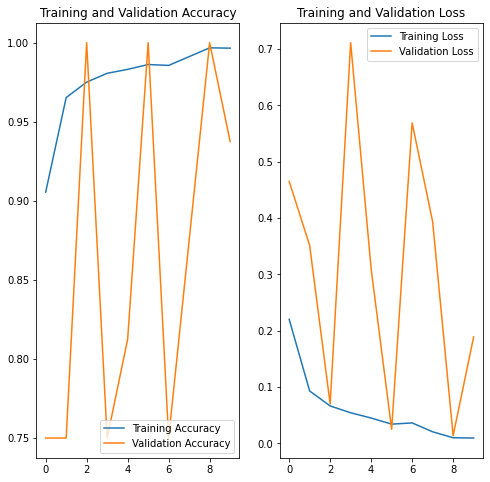

```python
acc = history.history['accuracy']
val_acc = history.history['val_accuracy']

loss = history.history['loss']
val_loss = history.history['val_loss']

epochs_range = range(epochs)

plt.figure(figsize=(8, 8))
plt.subplot(1, 2, 1)
plt.plot(epochs_range, acc, label='Training Accuracy')
plt.plot(epochs_range, val_acc, label='Validation Accuracy')
plt.legend(loc='lower right')
plt.title('Training and Validation Accuracy')

plt.subplot(1, 2, 2)
plt.plot(epochs_range, loss, label='Training Loss')
plt.plot(epochs_range, val_loss, label='Validation Loss')
plt.legend(loc='upper right')
plt.title('Training and Validation Loss')
plt.show()
```

### Augmentation du jeu de données

```python
data_augmentation = keras.Sequential(
    [
        layers.RandomFlip("horizontal",
                          input_shape=(img_height,
                                       img_width,
                                       1)),
        layers.RandomRotation(0.1),
        layers.RandomZoom(0.1),
    ]
)
```

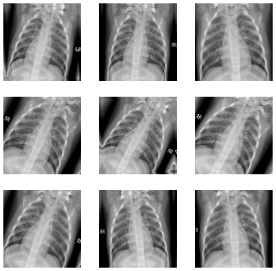

```python
plt.figure(figsize=(10, 10))
for images, _ in train_ds.take(1):
    for i in range(9):
        augmented_images = data_augmentation(images)
        ax = plt.subplot(3, 3, i + 1)
        plt.imshow(augmented_images[0].numpy().astype("uint8"), cmap = plt.cm.gray)
        plt.axis("off")
```

### Définition et compilation du modèle

```python
model = Sequential([
    data_augmentation,
    layers.Rescaling(1. / 255),
    layers.Conv2D(16, 3, padding='same', activation='relu'),
    layers.MaxPooling2D(),
    layers.Conv2D(32, 3, padding='same', activation='relu'),
    layers.MaxPooling2D(),
    layers.Conv2D(64, 3, padding='same', activation='relu'),
    layers.MaxPooling2D(),
    layers.Dropout(0.2),
    layers.Flatten(),
    layers.Dense(128, activation='relu'),
    layers.Dense(num_classes)
])
```

```python
model.compile(optimizer='adam',
              loss=tf.keras.losses.SparseCategoricalCrossentropy(from_logits=True),
              metrics=['accuracy'])
```

```python
model.summary()
```

```
Model: "sequential_2"
_________________________________________________________________
 Layer (type)                Output Shape              Param #
=================================================================
 sequential_1 (Sequential)   (None, 180, 180, 1)       0

 rescaling_1 (Rescaling)     (None, 180, 180, 1)       0

 conv2d_3 (Conv2D)           (None, 180, 180, 16)      160

 max_pooling2d_3 (MaxPooling  (None, 90, 90, 16)       0
 2D)

 conv2d_4 (Conv2D)           (None, 90, 90, 32)        4640

 max_pooling2d_4 (MaxPooling  (None, 45, 45, 32)       0
 2D)

 conv2d_5 (Conv2D)           (None, 45, 45, 64)        18496

 max_pooling2d_5 (MaxPooling  (None, 22, 22, 64)       0
 2D)

 dropout (Dropout)           (None, 22, 22, 64)        0

 flatten_1 (Flatten)         (None, 30976)             0

 dense_2 (Dense)             (None, 128)               3965056

 dense_3 (Dense)             (None, 2)                 258

=================================================================
Total params: 3,988,610
Trainable params: 3,988,610
Non-trainable params: 0
_________________________________________________________________
```

### Entrainement du modèle avec le dataset augmenté

```python
epochs = 15
history = model.fit(
    train_ds,
    validation_data=val_ds,
    epochs=epochs
)
```

### Graphique représentant l'entrainement du dataset augmenté

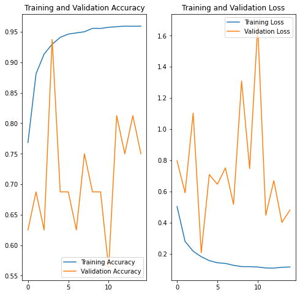

```python
acc = history.history['accuracy']
val_acc = history.history['val_accuracy']

loss = history.history['loss']
val_loss = history.history['val_loss']

epochs_range = range(epochs)

plt.figure(figsize=(8, 8))
plt.subplot(1, 2, 1)
plt.plot(epochs_range, acc, label='Training Accuracy')
plt.plot(epochs_range, val_acc, label='Validation Accuracy')
plt.legend(loc='lower right')
plt.title('Training and Validation Accuracy')

plt.subplot(1, 2, 2)
plt.plot(epochs_range, loss, label='Training Loss')
plt.plot(epochs_range, val_loss, label='Validation Loss')
plt.legend(loc='upper right')
plt.title('Training and Validation Loss')
plt.show()
```

### Utilisation du modèle à fin de prédiction, et graphique des résultats de précisions obtenus

```
Found 624 files belonging to 2 classes.
```

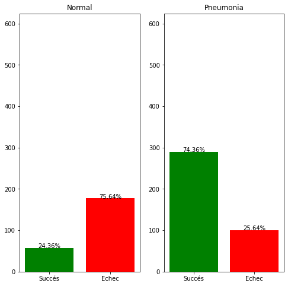

```python
data_dir_test = pathlib.Path('chest_Xray/test')
test_ds = tf.keras.utils.image_dataset_from_directory(
    data_dir_test,
    labels="inferred",
    seed=123,
    color_mode="grayscale",
    image_size=(img_height, img_width),
    batch_size=batch_size)

predictions = model.predict(test_ds)

labels = np.concatenate([y for x, y in test_ds], axis=0)
if len(predictions) == len(labels):
    output = [[0,0],[0,0]]
    for index, value in enumerate(predictions):
        if labels[index] == 0:
            if labels[index] == np.argmax(tf.nn.softmax(value)):
                output[0][0] += 1
            else:
                output[0][1] += 1
        else:
            if labels[index] == np.argmax(tf.nn.softmax(value)):
                output[1][0] += 1
            else:
                output[1][1] += 1

    X = np.arange(2)
    fig = plt.figure()
    plt.figure(figsize=(8, 8))
    plt.subplot(1,2,1)
    bars = plt.bar(X, output[0], color=['g', 'r'])
    for bar in bars:
        height = bar.get_height()
        val = round((height/(output[0][0]+output[0][1]))*100,2)
        plt.text(x=bar.get_x() + bar.get_width() / 2, y=height+.10,
        s="{}%".format(val),
        ha='center')
    plt.ylim(0, len(predictions))
    plt.xticks(X, ['Succés', 'Echec'], )
    plt.title('Normal')
    plt.subplot(1,2,2)
    bars = plt.bar(X, output[1], color=['g', 'r'])
    for bar in bars:
        height = bar.get_height()
        val = round((height/(output[1][0]+output[1][1]))*100,2)
        plt.text(x=bar.get_x() + bar.get_width() / 2, y=height+.10,
                 s="{}%".format(val),
                 ha='center')
    plt.ylim(0, len(predictions))
    plt.xticks(X, ['Succés', 'Echec'])
    plt.title('Pneumonia')
```

# Utilisation de la méthode Treshold

```python
import os
import cv2
import numpy as np
from matplotlib import pyplot as plt

import keras


from keras.preprocessing.image import ImageDataGenerator


from keras.models import Sequential
from keras.layers import Dense
from keras.layers import Conv2D
from keras.layers import MaxPool2D
from keras.layers import Flatten
from keras.layers import Dropout
from keras.layers import BatchNormalization
from sklearn.metrics import classification_report
```

```python
image_size = 200
labels = ['PNEUMONIA', 'NORMAL']
scale = 0.1
epochs=10
```

### Récupération des datasets en échelle de gris

```python
def get_training_data(data_dir):
    data = list()
    for label in labels:
        path = os.path.join(data_dir, label)
        class_num = labels.index(label)
        for image in os.listdir(path):
            if(image!=".DS_Store"):
                try:
                    image_arr = cv2.imread(os.path.join(path, image), cv2.IMREAD_GRAYSCALE)
                    resized_arr = cv2.resize(image_arr, (image_size, image_size))
                    data.append([resized_arr, class_num])
                except Exception as e:
                    print(e)
    # return np.array(data, dtype="object")
    dataset= np.array(data, dtype="object")
    return dataset[np.random.randint(dataset.shape[0], size=int(len(dataset)*scale)), :]
```

```python
trainData = get_training_data('chest_xray/train')
testData = get_training_data('chest_xray/test')
valData = get_training_data('chest_xray/val')
print(f"Train: {len(trainData)}, Test: {len(testData)}, Val: {len(valData)}")
```

```
Train: 521, Test: 62, Val: 1
```

### Affichage d'une image du dataset de data

/!\ passer paramètre plt.cm.gray à imshow sinon plt transforme le vecteur gris de cv2 en vert

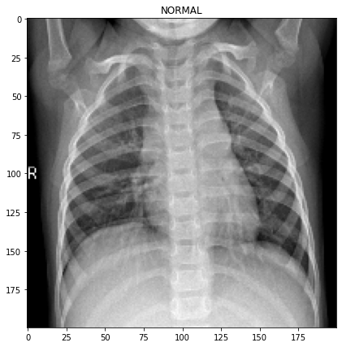

```python
plt.figure(figsize = (7, 7))
plt.imshow(trainData[2][0], cmap = plt.cm.gray)
plt.title(labels[trainData[2][1]])
```

#### Tresholding : technique de segmentation pour séparer le premier plan du background

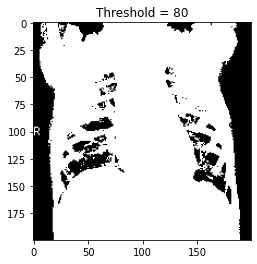

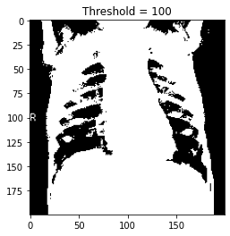

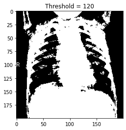

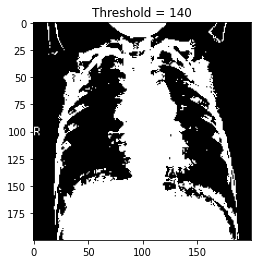

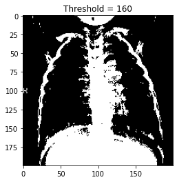

```python
sample = trainData[2][0]

rgb = cv2.cvtColor(sample, cv2.COLOR_BGR2RGB)
gray = cv2.cvtColor(rgb, cv2.COLOR_RGB2GRAY)

thresholds = [80, 100, 120, 140, 160]
for threshold in thresholds:
    val, thresh = cv2.threshold(gray, threshold, 255, cv2.THRESH_BINARY)
    plt.imshow(thresh, cmap='gray')
    plt.title(f"Threshold = {threshold}")
    plt.show()
```

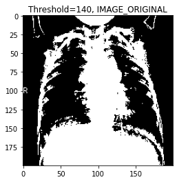

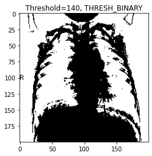

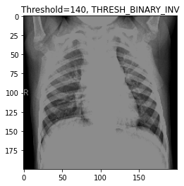

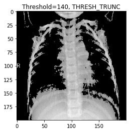

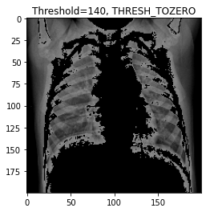

```python
def show_threshold(image, threshold):
    cv2_threshs = [cv2.THRESH_BINARY, cv2.THRESH_BINARY_INV, cv2.THRESH_TRUNC,
                  cv2.THRESH_TOZERO, cv2.THRESH_TOZERO_INV]

    names = ['IMAGE_ORIGINAL', 'THRESH_BINARY', 'THRESH_BINARY_INV', 'THRESH_TRUNC',
                'THRESH_TOZERO', 'THRESH_TOZERO_INV']


    for name, cv2_thresh in zip(names, cv2_threshs):
        val, image_new = cv2.threshold(image, threshold, 255, cv2_thresh)
        plt.imshow(cv2.cvtColor(image_new, cv2.COLOR_BGR2RGB), cmap='gray')
        plt.title(f"Threshold={threshold}, {name}")
        plt.show()
show_threshold(gray, 140)
```

```python
def prepare_dataset(dataset):
    X_ = list()
    y_ = list()
    for features, label in dataset:
        X_.append(features)
        y_.append(label)
    X_ = np.array(X_)/255
    X_ = X_.reshape(-1, image_size, image_size, 1)
    y_ = np.array(y_)
    return X_, y_
```

```python
X_train, y_train = prepare_dataset(trainData)
X_test, y_test = prepare_dataset(testData)
```

#### ImageDataGenerator :

applique à un batch d’images, des transformations choisies de façon aléatoire et remplace le batch d’origine par ces nouvelles donnée

```python
def data_argumentation(datagen=None):
    if datagen is None:
        return ImageDataGenerator(
                    featurewise_center=False,
                    samplewise_center=False,
                    featurewise_std_normalization=False,
                    samplewise_std_normalization=False,
                    zca_whitening=False,
                    rotation_range = 30)
    return datagen
```

```python
datagenerator = data_argumentation()
```

```python
datagenerator.fit(X_train)
```

```python
def model_v1(img_size):
    model_v1 = Sequential()

    model_v1.add(Conv2D(32, (3,3), strides=1, padding='same', activation='relu', input_shape=img_size))
    model_v1.add(BatchNormalization())
    model_v1.add(MaxPool2D((2,2), strides=2, padding='same'))

    model_v1.add(Conv2D(64, (3,3), strides=1, padding='same', activation='relu'))
    model_v1.add(Dropout(0.2))

    model_v1.add(BatchNormalization())
    model_v1.add(MaxPool2D((2,2), strides=2, padding='same'))
    model_v1.add(Conv2D(64, (3,3), strides=1, padding='same', activation='relu'))

    model_v1.add(BatchNormalization())
    model_v1.add(MaxPool2D((2,2), strides=2, padding='same'))
    model_v1.add(Conv2D(128, (3,3), strides=1, padding='same', activation='relu'))
    model_v1.add(Dropout(0.2))

    model_v1.add(BatchNormalization())
    model_v1.add(MaxPool2D((2,2), strides = 2, padding='same'))

    model_v1.add(Flatten())
    model_v1.add(Dense(units=128, activation='relu'))
    model_v1.add(Dropout(0.2))
    model_v1.add(Dense(2, activation='softmax'))

    return model_v1
```

```python
def model_v2(img_size):
    model_v2 = Sequential()
    model_v2.add(Conv2D(32, (3, 3), activation='relu', input_shape=img_size))
    model_v2.add(MaxPool2D((2, 2)))
    model_v2.add(Dropout(0.2))

    model_v2.add(Conv2D(64, (3, 3), activation='relu'))
    model_v2.add(MaxPool2D((2, 2)))
    model_v2.add(Dropout(0.2))

    model_v2.add(Conv2D(64, (3, 3), activation='relu'))
    model_v2.add(MaxPool2D((2, 2)))
    model_v2.add(Dropout(0.2))

    model_v2.add(Conv2D(128, (3, 3), activation='relu'))
    model_v2.add(MaxPool2D((2, 2)))

    model_v2.add(Flatten())
    model_v2.add(Dense(120))
    model_v2.add(Dropout(0.4))
    model_v2.add(Dense(2, activation='softmax'))

    return model_v2
```

```python
model_v1 = model_v1((image_size, image_size, 1))
model_v2 = model_v2((image_size, image_size, 1))
```

```python
model_v1.compile(optimizer='adam', loss='sparse_categorical_crossentropy',metrics=['accuracy'])
model_v1.summary()
```

```
Model: "sequential_3"
_________________________________________________________________
 Layer (type)                Output Shape              Param #
=================================================================
 conv2d_6 (Conv2D)           (None, 200, 200, 32)      320

 batch_normalization (BatchN  (None, 200, 200, 32)     128
 ormalization)

 max_pooling2d_6 (MaxPooling  (None, 100, 100, 32)     0
 2D)

 conv2d_7 (Conv2D)           (None, 100, 100, 64)      18496

 dropout_1 (Dropout)         (None, 100, 100, 64)      0

 batch_normalization_1 (Batc  (None, 100, 100, 64)     256
 hNormalization)

 max_pooling2d_7 (MaxPooling  (None, 50, 50, 64)       0
 2D)

 conv2d_8 (Conv2D)           (None, 50, 50, 64)        36928

 batch_normalization_2 (Batc  (None, 50, 50, 64)       256
 hNormalization)

 max_pooling2d_8 (MaxPooling  (None, 25, 25, 64)       0
 2D)

 conv2d_9 (Conv2D)           (None, 25, 25, 128)       73856

 dropout_2 (Dropout)         (None, 25, 25, 128)       0

 batch_normalization_3 (Batc  (None, 25, 25, 128)      512
 hNormalization)

 max_pooling2d_9 (MaxPooling  (None, 13, 13, 128)      0
 2D)

 flatten_2 (Flatten)         (None, 21632)             0

 dense_4 (Dense)             (None, 128)               2769024

 dropout_3 (Dropout)         (None, 128)               0

 dense_5 (Dense)             (None, 2)                 258

=================================================================
Total params: 2,900,034
Trainable params: 2,899,458
Non-trainable params: 576
_________________________________________________________________
```

```python
model_v2.compile(optimizer='adam', loss='sparse_categorical_crossentropy',metrics=['accuracy'])
model_v2.summary()
```

```
Model: "sequential_4"
_________________________________________________________________
 Layer (type)                Output Shape              Param #
=================================================================
 conv2d_10 (Conv2D)          (None, 198, 198, 32)      320

 max_pooling2d_10 (MaxPoolin  (None, 99, 99, 32)       0
 g2D)

 dropout_4 (Dropout)         (None, 99, 99, 32)        0

 conv2d_11 (Conv2D)          (None, 97, 97, 64)        18496

 max_pooling2d_11 (MaxPoolin  (None, 48, 48, 64)       0
 g2D)

 dropout_5 (Dropout)         (None, 48, 48, 64)        0

 conv2d_12 (Conv2D)          (None, 46, 46, 64)        36928

 max_pooling2d_12 (MaxPoolin  (None, 23, 23, 64)       0
 g2D)

 dropout_6 (Dropout)         (None, 23, 23, 64)        0

 conv2d_13 (Conv2D)          (None, 21, 21, 128)       73856

 max_pooling2d_13 (MaxPoolin  (None, 10, 10, 128)      0
 g2D)

 flatten_3 (Flatten)         (None, 12800)             0

 dense_6 (Dense)             (None, 120)               1536120

 dropout_7 (Dropout)         (None, 120)               0

 dense_7 (Dense)             (None, 2)                 242

=================================================================
Total params: 1,665,962
Trainable params: 1,665,962
Non-trainable params: 0
_________________________________________________________________
```

#### ModelCheckpoint :

Sauvegarde du meilleur model (parametre save_best_only)

#### EarlyStopping :

Quand plus d'évolution, stop du model

```python
def callbacks():
    callbacks = [
            keras.callbacks.ModelCheckpoint(
                filepath='lstmchar256256128test.h5',
                monitor='loss',
                save_best_only=True
            ),
            keras.callbacks.EarlyStopping(
                monitor='loss',
                min_delta=0,
                patience=8,
                mode='auto',
                baseline=None,
            )
        ]
    return callbacks
```

### Fit :

Entrainement avec les valeurs de train, ajustement des neurones

```python
history_v1 = model_v1.fit(datagenerator.flow(X_train, y_train, batch_size=32),
                    epochs=epochs, callbacks=callbacks())
```

```python
history_v2 = model_v2.fit(datagenerator.flow(X_train, y_train, batch_size=32),
                    epochs=epochs, callbacks=callbacks())
```

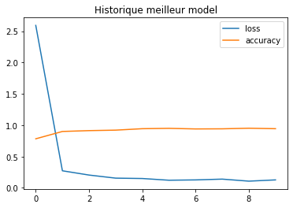

```python
history_loss = history_v1.history["loss"]
history_acc = history_v1.history["accuracy"]

plt.plot(history_loss, label="loss")
plt.plot(history_acc, label="accuracy")
plt.title("Historique meilleur model")
plt.legend()
```

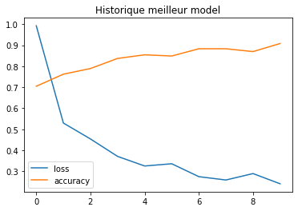

```python
history_loss = history_v2.history["loss"]
history_acc = history_v2.history["accuracy"]

plt.plot(history_loss, label="loss")
plt.plot(history_acc, label="accuracy")
plt.title("Historique meilleur model")
plt.legend()
```

#### predict :

Utilisation du model pour la détermination de la pneumonie. On ajuste plus, on test notre model avec notre dataset de test.

```python
predict_x=model_v1.predict(X_test)
classes_x=np.argmax(predict_x, axis=1)
len(classes_x), len(X_test)
```

```
(62, 62)
```

```python
print(classification_report(y_test, classes_x, target_names=labels))
```

```
              precision    recall  f1-score   support

   PNEUMONIA       0.65      1.00      0.78        40
      NORMAL       0.00      0.00      0.00        22

    accuracy                           0.65        62
   macro avg       0.32      0.50      0.39        62
weighted avg       0.42      0.65      0.51        62
```

```python
predict_x=model_v2.predict(X_test)
classes_x=np.argmax(predict_x, axis=1)
len(classes_x), len(X_test)
```

```
(62, 62)
```

```python
print(classification_report(y_test, classes_x, target_names=labels))
```

```
              precision    recall  f1-score   support

   PNEUMONIA       0.92      0.85      0.88        40
      NORMAL       0.76      0.86      0.81        22

    accuracy                           0.85        62
   macro avg       0.84      0.86      0.85        62
weighted avg       0.86      0.85      0.86        62
```

# Utilisation de la méthode KNN

Import dependencies

```python
import numpy as np
import matplotlib.pyplot as plt
import cv2
import os
import time
from sklearn.metrics import classification_report
from sklearn.neighbors import KNeighborsClassifier
from sklearn.decomposition import PCA
from sklearn import metrics
from sklearn.metrics import confusion_matrix
from sklearn.model_selection import train_test_split
from sklearn.preprocessing import StandardScaler
import itertools
%matplotlib inline
```

Const

```python
train_path = r'chest_Xray/train'
test_path = r'chest_Xray/test'
val_path = r'chest_Xray/val'

labels = ['NORMAL', 'PNEUMONIA']

IMG_SIZE=200

scale = 0.7

pca = PCA(.95)
```

Import images into array function

```python
def get_training_data(data_dir, size):
    data = list()
    for label in labels:
        path = os.path.join(data_dir, label)
        class_num = labels.index(label)
        for image in os.listdir(path):
            if(image!=".DS_Store"):
                try:
                    image_arr = cv2.imread(os.path.join(path, image), cv2.IMREAD_GRAYSCALE)
                    resized_arr = cv2.resize(image_arr, (size, size))
                    data.append([resized_arr, class_num])
                except Exception as e:
                    print(e)
    return np.array(data, dtype="object")
```

```python
test = get_training_data(test_path, IMG_SIZE)
train = get_training_data(train_path, IMG_SIZE)
val = get_training_data(val_path, IMG_SIZE)
```

Balence datasets

```python
def mix_datasets(array):
    # Pneumonie
    arr_1 = array[np.where(array[:,1] == 1)]
    # Normal
    arr_0 = array[np.where(array[:,1] == 0)]
    l_arr_1 = len(arr_1)
    l_arr_0 = len(arr_0)
    diff = 0

    if l_arr_0 > l_arr_1:
        diff = l_arr_0 - l_arr_1
        arr_0.resize((l_arr_0 - diff, arr_0.shape[1]))
        array = np.concatenate((l_arr_0, arr_1))
    else:
        diff = l_arr_1 - l_arr_0
        arr_1.resize((l_arr_1 - diff, arr_1.shape[1]))
        array = np.concatenate((arr_0, arr_1))
    return array
```

Scaling datsets

```python
# # train_scaled = train
# test_scaled = test
# train_scaled = train[np.random.randint(train.shape[0], size=int(len(train)*scale)), :]
# # test_scaled = test[np.random.randint(test.shape[0], size=int(len(test)*scale)), :]
```

Preparing the data

```python
def prepare_dataset(dataset):
    X_ = list()
    y_ = list()
    for features, label in dataset:
        X_.append(features)
        y_.append(label)
    X_ = np.array(X_)
    X_ = X_.reshape(-1, IMG_SIZE * IMG_SIZE)
    y_ = np.array(y_)
    return X_, y_
```

```python
x_train, label_train = prepare_dataset(mix_datasets(train))
x_test, label_test = prepare_dataset(mix_datasets(test))
x_val, label_val = prepare_dataset(mix_datasets(val))
```

Train test split

```python
# Append train + test data in order to scale our datasets
X = np.concatenate((x_train, x_test))
X = np.concatenate((X, x_val))
Y = np.concatenate((label_train, label_test))
Y = np.concatenate((Y, label_val))
```

```python
# test_size: what proportion of original data is used for test set
x_train, x_test, label_train, label_test = train_test_split( X, Y, test_size=0.30)
```

Transform / Normalize data

```python
scaler = StandardScaler()
# Fit on training set only.
scaler.fit(x_train)
# Apply transform to both the training set and the test set.
x_train = scaler.transform(x_train)
x_test = scaler.transform(x_test)
```

Apply PCA

```python
pca.fit(x_train)
x_train = pca.transform(x_train)
x_test = pca.transform(x_test)
```

Find Best numbers of neighbors

```python
# try K=1 through K=15 and record testing accuracy
k_range = range(1, 16)

# We can create Python dictionary using [] or dict()
scores = []

# We use a loop through the range 1 to 26
# We append the scores in the dictionary
for k in k_range:
    knn = KNeighborsClassifier(n_neighbors=k)
    knn.fit(x_train, label_train)
    y_pred = knn.predict(x_test)
    scores.append(metrics.accuracy_score(label_test, y_pred))

max = np.amax(scores)
itemindex = np.where(scores==max)
neighbors_max = itemindex[0]+1
```

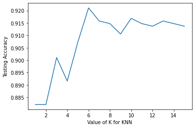

```python
# plot the relationship between K and testing accuracy
# plt.plot(x_axis, y_axis)
plt.plot(k_range, scores)
plt.xlabel('Value of K for KNN')
plt.ylabel('Testing Accuracy')
```

### Final model

train

```python
time1 = time.time()

KNN = KNeighborsClassifier(int(neighbors_max[0]))
KNN.fit(x_train, label_train)

# Print duration time
duration_time = time.time() - time1
if duration_time < 60 :
    print("{} s".format(duration_time))
else :
    print("{} min".format(duration_time/60))
```

```
0.0029921531677246094 s
```

Predict

```python
pred = KNN.predict(x_test)
```

```python
# predicted_classes = np.argmax(pred, axis=0)
print(metrics.accuracy_score(pred, label_test))
report = classification_report(pred, label_test, target_names=labels)
print(report)
```

```
0.9210526315789473
              precision    recall  f1-score   support

      NORMAL       0.91      0.92      0.92       457
   PNEUMONIA       0.93      0.92      0.92       493

    accuracy                           0.92       950
   macro avg       0.92      0.92      0.92       950
weighted avg       0.92      0.92      0.92       950
```

Confusion matrix

```python
def plot_confusion_matrix(cm, classes,
                        normalize=False,
                        title='Confusion matrix',
                        cmap=plt.cm.Blues):
    """
    This function prints and plots the confusion matrix.
    Normalization can be applied by setting `normalize=True`.
    """
    plt.imshow(cm, interpolation='nearest', cmap=cmap)
    plt.title(title)
    plt.colorbar()
    tick_marks = np.arange(len(classes))
    plt.xticks(tick_marks, classes, rotation=45)
    plt.yticks(tick_marks, classes)

    if normalize:
        cm = cm.astype('float') / cm.sum(axis=1)[:, np.newaxis]
        print("Normalized confusion matrix")
    else:
        print('Confusion matrix, without normalization')

    print(cm)

    thresh = cm.max() / 2.
    for i, j in itertools.product(range(cm.shape[0]), range(cm.shape[1])):
        plt.text(j, i, cm[i, j],
            horizontalalignment="center",
            color="white" if cm[i, j] > thresh else "black")

    plt.tight_layout()
    plt.ylabel('True label')
    plt.xlabel('Predicted label')
```

```python
cm = confusion_matrix(y_true=label_test, y_pred=pred)
```

```
Confusion matrix, without normalization
[[422  40]
 [ 35 453]]
```

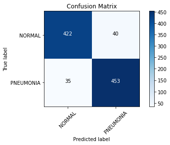

```python
plot_confusion_matrix(cm=cm, classes=labels, title='Confusion Matrix')
```

```python
score = KNN.score(x_test, label_test)

print(f'Test accuracy : {score:4.4f}')
```

```
Test accuracy : 0.9211
```

# Utilisation de la méthode de Convolution

Import dependencies

```python
%matplotlib inline
import matplotlib.pyplot as plt
import numpy as np
import tensorflow as tf
import cv2
import os
import time
from sklearn.metrics import classification_report
from sklearn.model_selection import train_test_split
from sklearn.metrics import confusion_matrix
import itertools
from tensorflow.keras import layers, models
```

Const

```python
train_path = r'chest_Xray\train'
test_path = r'chest_Xray\test'
val_path = r'chest_Xray/val'

labels = ['NORMAL', 'PNEUMONIA']

IMG_SIZE=200

scale = 1
```

Import images into array function

```python
def get_training_data(data_dir, size):
    data = list()
    for label in labels:
        path = os.path.join(data_dir, label)
        class_num = labels.index(label)
        for image in os.listdir(path):
            if(image!=".DS_Store"):
                try:
                    image_arr = cv2.imread(os.path.join(path, image), cv2.IMREAD_GRAYSCALE)
                    resized_arr = cv2.resize(image_arr, (size, size))
                    data.append([resized_arr, class_num])
                except Exception as e:
                    print(e)
    return np.array(data, dtype="object")
```

```python
# x_train, label_train = create_dataset(train_path, IMG_SIZE)
# x_test, label_test = create_dataset(test_path, IMG_SIZE)
```

```python
test = get_training_data(test_path, IMG_SIZE)
train = get_training_data(train_path, IMG_SIZE)
val = get_training_data(val_path, IMG_SIZE)
```

Balence datasets

```python
def mix_datasets(array):
    # Pneumonie
    arr_1 = array[np.where(array[:,1] == 1)]
    # Normal
    arr_0 = array[np.where(array[:,1] == 0)]
    l_arr_1 = len(arr_1)
    l_arr_0 = len(arr_0)
    diff = 0

    if l_arr_0 > l_arr_1:
        diff = l_arr_0 - l_arr_1
        arr_0.resize((l_arr_0 - diff, arr_0.shape[1]))
        array = np.concatenate((l_arr_0, arr_1))
    else:
        diff = l_arr_1 - l_arr_0
        arr_1.resize((l_arr_1 - diff, arr_1.shape[1]))
        array = np.concatenate((arr_0, arr_1))
    return array
```

Scaling datsets

```python
# train_scaled = train
# test_scaled = test
train_scaled = train[np.random.randint(train.shape[0], size=int(len(train)*scale)), :]
test_scaled = test[np.random.randint(test.shape[0], size=int(len(test)*scale)), :]
```

Preparing the data

```python
def prepare_dataset(dataset):
    X_ = list()
    y_ = list()
    for features, label in dataset:
        X_.append(features)
        y_.append(label)
    X_ = np.array(X_)
    X_ = X_.reshape(-1, IMG_SIZE, IMG_SIZE, 1)
    y_ = np.array(y_)
    return X_, y_
```

```python
x_train, label_train = prepare_dataset(mix_datasets(train))
x_test, label_test = prepare_dataset(mix_datasets(test))
x_val, label_val = prepare_dataset(mix_datasets(val))
```

```python
# Append train + test + val data in order to scale our datasets
X = np.concatenate((x_train, x_test))
X = np.concatenate((X, x_val))
Y = np.concatenate((label_train, label_test))
Y = np.concatenate((Y, label_val))
```

```python
# Hold-Out cross validation
# test_size: what proportion of original data is used for test set
x_train, x_test, label_train, label_test = train_test_split( X, Y, test_size=0.30)
```

Normalize data

```python
xmax = np.array(x_train).max()
x_train = x_train / xmax
xmax = np.array(x_test).max()
x_test  = x_test  / xmax
```

Create model

```python
model = models.Sequential()
model.add(layers.Conv2D(32, (3, 3), activation='relu', input_shape=(IMG_SIZE, IMG_SIZE, 1)))
model.add(layers.MaxPooling2D((2, 2)))
# model.add(layers.Dropout(0.2))

model.add(layers.Conv2D(64, (3, 3), activation='relu'))
model.add(layers.MaxPooling2D((2, 2)))
# model.add(layers.Dropout(0.2))

model.add(layers.Conv2D(64, (3, 3), activation='relu'))
model.add(layers.MaxPooling2D((2, 2)))
# model.add(layers.Dropout(0.2))

model.add(layers.Conv2D(128, (3, 3), activation='relu'))
model.add(layers.MaxPooling2D((2, 2)))

model.add(layers.Flatten())
model.add(layers.Dense(120))
# model.add(layers.Dropout(0.4))
model.add(layers.Dense(2, activation='softmax'))
```

Init training's Callback

```python
def callbacks():
    callbacks = [
            tf.keras.callbacks.ModelCheckpoint(
                filepath='lstmchar256256128test.h5',
                monitor='loss',
                save_best_only=True
            ),
            tf.keras.callbacks.EarlyStopping(
                monitor='loss',
                min_delta=0,
                patience=4,
                mode='auto',
                baseline=None,
            )
        ]
    return callbacks
```

```python
model.summary()
```

```
Model: "sequential_5"
_________________________________________________________________
 Layer (type)                Output Shape              Param #
=================================================================
 conv2d_14 (Conv2D)          (None, 198, 198, 32)      320

 max_pooling2d_14 (MaxPoolin  (None, 99, 99, 32)       0
 g2D)

 conv2d_15 (Conv2D)          (None, 97, 97, 64)        18496

 max_pooling2d_15 (MaxPoolin  (None, 48, 48, 64)       0
 g2D)

 conv2d_16 (Conv2D)          (None, 46, 46, 64)        36928

 max_pooling2d_16 (MaxPoolin  (None, 23, 23, 64)       0
 g2D)

 conv2d_17 (Conv2D)          (None, 21, 21, 128)       73856

 max_pooling2d_17 (MaxPoolin  (None, 10, 10, 128)      0
 g2D)

 flatten_4 (Flatten)         (None, 12800)             0

 dense_8 (Dense)             (None, 120)               1536120

 dense_9 (Dense)             (None, 2)                 242

=================================================================
Total params: 1,665,962
Trainable params: 1,665,962
Non-trainable params: 0
_________________________________________________________________
```

Compile + train model

```python
# y_test = np.array(y_test)
# y_train = np.array(y_train)
y_test = np.array(label_test)
y_train = np.array(label_train)
```

```python
model.compile(optimizer='adam',
              loss=tf.keras.losses.SparseCategoricalCrossentropy(from_logits=True),
              metrics=['accuracy'])

time1 = time.time()
history = model.fit(x_train, y_train, epochs=10, validation_data=(x_test, y_test), callbacks=callbacks())

# Print duration time
duration_time = time.time() - time1
if duration_time < 60 :
    print("{} s".format(duration_time))
else :
    print("{} min".format(duration_time/60))
```

```
29.692190170288086 s
```

loss + accuracy graph

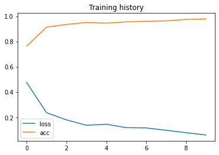

```python
history_loss = history.history["loss"]
history_acc = history.history["accuracy"]

plt.plot(history_loss, label="loss")
plt.plot(history_acc, label="acc")
plt.title("Training history")
plt.legend()
```

Prediction

```python
pred = model.predict(x_test)
```

```python
predicted_classes = np.argmax(pred, axis=1)
report = classification_report(predicted_classes, y_test, target_names=labels)
print(report)
```

```
              precision    recall  f1-score   support

      NORMAL       0.93      0.96      0.94       459
   PNEUMONIA       0.96      0.93      0.95       491

    accuracy                           0.95       950
   macro avg       0.95      0.95      0.95       950
weighted avg       0.95      0.95      0.95       950
```

Cunsion matrix

```python
def plot_confusion_matrix(cm, classes,
                        normalize=False,
                        title='Confusion matrix',
                        cmap=plt.cm.Blues):
    """
    This function prints and plots the confusion matrix.
    Normalization can be applied by setting `normalize=True`.
    """
    plt.imshow(cm, interpolation='nearest', cmap=cmap)
    plt.title(title)
    plt.colorbar()
    tick_marks = np.arange(len(classes))
    plt.xticks(tick_marks, classes, rotation=45)
    plt.yticks(tick_marks, classes)

    if normalize:
        cm = cm.astype('float') / cm.sum(axis=1)[:, np.newaxis]
        print("Normalized confusion matrix")
    else:
        print('Confusion matrix, without normalization')

    print(cm)

    thresh = cm.max() / 2.
    for i, j in itertools.product(range(cm.shape[0]), range(cm.shape[1])):
        plt.text(j, i, cm[i, j],
            horizontalalignment="center",
            color="white" if cm[i, j] > thresh else "black")

    plt.tight_layout()
    plt.ylabel('True label')
    plt.xlabel('Predicted label')
```

```python
cm = confusion_matrix(y_true=label_test, y_pred=predicted_classes)
```

```
Confusion matrix, without normalization
[[442  35]
 [ 17 456]]
```

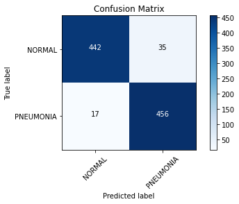

```python
plot_confusion_matrix(cm=cm, classes=labels, title='Confusion Matrix')
```

```python
score = model.evaluate(x_test, y_test, verbose=0)

print(f'Test loss     : {score[0]:4.4f}')
print(f'Test accuracy : {score[1]:4.4f}')
```

```
Test loss     : 0.1737
Test accuracy : 0.9453
```